# personal-loan-logistic-regression-decision-tree

- People with higher income had opted for personal loan before.
- People with high mortgages opted for loan.
- Customers with higher average monthly credit usage have opted for loan.
- Customers with higher income had higher average credit card usage and mortgage.
- Graduate and Advanced/Professional have higher monhtly credit card usage and have borrowed loans with the bank.

```python
## Function to plot stacked bar chart
def stacked_plot(x):
    sns.set_palette(sns.color_palette("Set2", 8))
    tab1 = pd.crosstab(x,df_loan['PersonalLoan'],margins=True)
    print(tab1)
    print('-'*120)
    tab = pd.crosstab(x,df_loan['PersonalLoan'],normalize='index')
    tab.plot(kind='bar',stacked=True,figsize=(7,4))
    plt.xticks(rotation=360)
    labels=["No","Yes"]
    plt.legend(loc='lower left', frameon=False,)
    plt.legend(loc="upper left", labels=labels,title="Borrowed Loan",bbox_to_anchor=(1,1))
    sns.despine(top=True,right=True,left=True) # to remove side line from graph
    #plt.legend(labels)
    plt.show()
```

```
PersonalLoan     0    1   All
Family
1             1365  107  1472
2             1190  106  1296
3              877  133  1010
4             1087  134  1221
All           4519  480  4999
------------------------------------------------------------------------------------------------------------------------
```

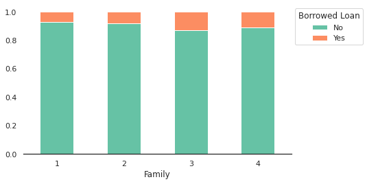

```
PersonalLoan     0    1   All
Education
1             2003   93  2096
2             1221  182  1403
3             1295  205  1500
All           4519  480  4999
------------------------------------------------------------------------------------------------------------------------
```

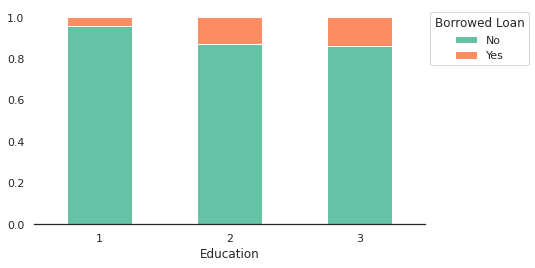

```
PersonalLoan          0    1   All
SecuritiesAccount
0                  4057  420  4477
1                   462   60   522
All                4519  480  4999
------------------------------------------------------------------------------------------------------------------------
```

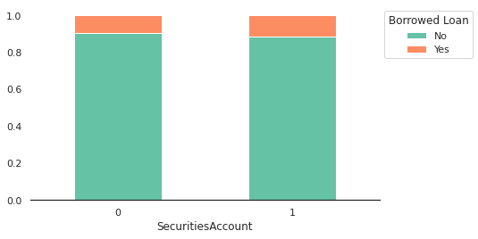

```
PersonalLoan     0    1   All
CDAccount
0             4357  340  4697
1              162  140   302
All           4519  480  4999
------------------------------------------------------------------------------------------------------------------------
```

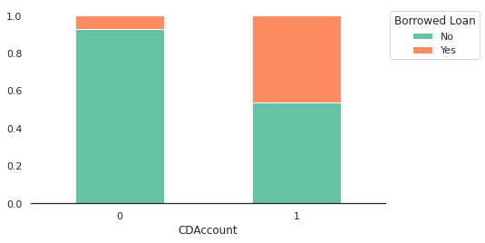

```
PersonalLoan     0    1   All
CreditCard
0             3193  337  3530
1             1326  143  1469
All           4519  480  4999
------------------------------------------------------------------------------------------------------------------------
```

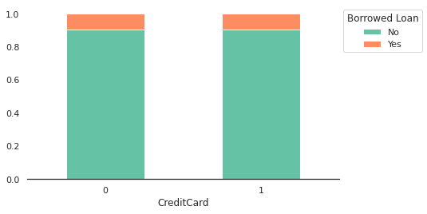

```
PersonalLoan     0    1   All
Online
0             1827  189  2016
1             2692  291  2983
All           4519  480  4999
------------------------------------------------------------------------------------------------------------------------
```

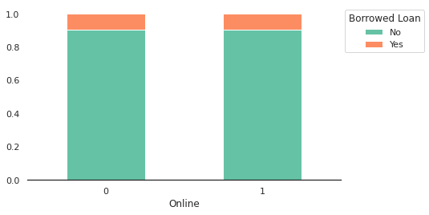

```
PersonalLoan           0    1   All
Regions
Bay Area            1747  196  1943
Central              390   30   420
Los Angeles Region   984  111  1095
Southern            1314  135  1449
Superior              84    8    92
All                 4519  480  4999
------------------------------------------------------------------------------------------------------------------------
```

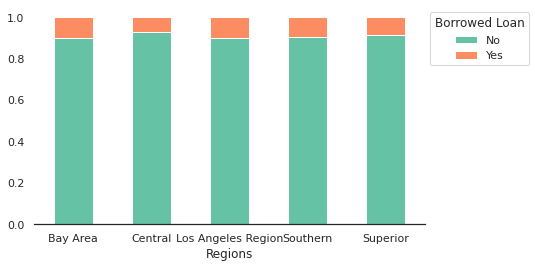

```
PersonalLoan     0    1   All
Agebin
18-30          558   66   624
31-40         1118  118  1236
41-50         1148  122  1270
51-60         1207  115  1322
60-100         488   59   547
All           4519  480  4999
------------------------------------------------------------------------------------------------------------------------
```

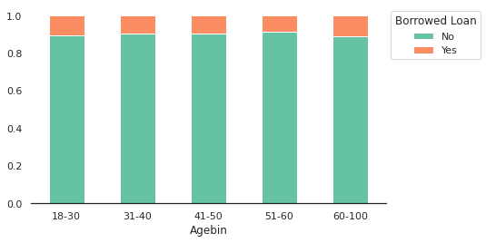

```
PersonalLoan     0    1   All
Income_group
Lower         1913    0  1913
Middle        2301  223  2524
High           305  257   562
All           4519  480  4999
------------------------------------------------------------------------------------------------------------------------
```

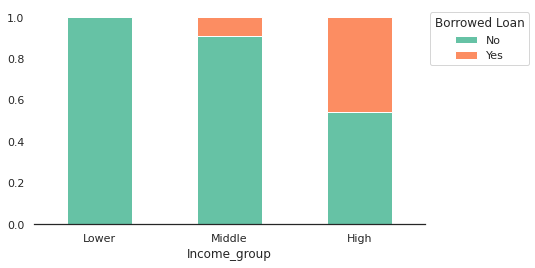

```
PersonalLoan       0    1   All
Spending_group
Low             1341   39  1380
Medium          2292   79  2371
High             886  362  1248
All             4519  480  4999
------------------------------------------------------------------------------------------------------------------------
```

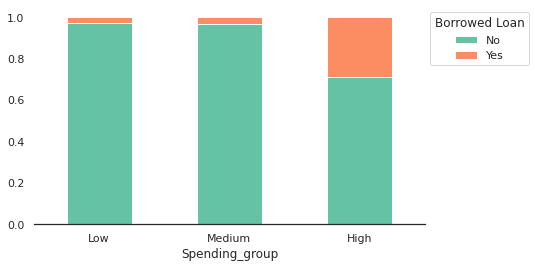

```python
cat_columns=['Family','Education','SecuritiesAccount','CDAccount','CreditCard','Online','Regions','Agebin','Income_group','Spending_group']
for i, variable in enumerate(cat_columns):
       stacked_plot(df_loan[variable])
```

**Observations**

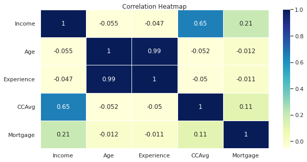

```python
plt.figure(figsize=(10,5))
numerical=['Income','Age','Experience','CCAvg','Mortgage']

# A better color to see the positive or negative correlation of each variable
heatmap = sns.heatmap(df_loan[numerical].corr(), annot=True, cmap='YlGnBu',linewidths=0.5)
heatmap.set_title('Correlation Heatmap', fontdict={'fontsize':12}, pad=2);
```

### Check distrubution in target column

[output not shown]

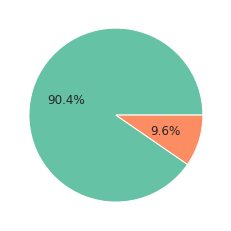

```python
plt.pie(data=df_loan,x=df_loan["PersonalLoan"].value_counts(),autopct='%1.1f%%')
```

The target variable personal_loan is highly imbalanced where only 9.6% of the customers have previously opted for a personal loan in the dataset. This can be handled using weight or SMOTE.But for now we will carry with on without SMOTE

```python
df_loan.head()
```

|  | Age | Experience | Income | ZIPCode | Family | CCAvg | Education | Mortgage | PersonalLoan | SecuritiesAccount | CDAccount | Online | CreditCard | County | Agebin | Income_group | Spending_group | Regions |
| --- | --- | --- | --- | --- | --- | --- | --- | --- | --- | --- | --- | --- | --- | --- | --- | --- | --- | --- |
| 0 | 25 | 1 | 49 | 91107 | 4 | 1.60000 | 1 | 0 | 0 | 1 | 0 | 0 | 0 | Los Angeles County | 18-30 | Lower | Medium | Los Angeles Region |
| 1 | 45 | 19 | 34 | 90089 | 3 | 1.50000 | 1 | 0 | 0 | 1 | 0 | 0 | 0 | Los Angeles County | 41-50 | Lower | Medium | Los Angeles Region |
| 2 | 39 | 15 | 11 | 94720 | 1 | 1.00000 | 1 | 0 | 0 | 0 | 0 | 0 | 0 | Alameda County | 31-40 | Lower | Medium | Bay Area |
| 3 | 35 | 9 | 100 | 94112 | 1 | 2.70000 | 2 | 0 | 0 | 0 | 0 | 0 | 0 | San Francisco County | 31-40 | Middle | High | Bay Area |
| 4 | 35 | 8 | 45 | 91330 | 4 | 1.00000 | 2 | 0 | 0 | 0 | 0 | 0 | 1 | Los Angeles County | 31-40 | Lower | Medium | Los Angeles Region |

```python
# Saving dataset before treating outliers for logistic regression.
df_Decision = df_loan.copy()
```

## Insights based on EDA

### Summary of EDA

**Data Description:**

- Dependent variable is the Personal_loan which is of categorical data type.
- Age, Experience, Income,mortage ,CCavg are of integer type while other variables are of categorical type
- There were no missing values in the dataset.

**Data Cleaning:**

- We observed that some observations where experience = -ve but since there was a strong correlation with age , we dropped experience.
- There are 450 unique zipcode, we mapped it to counties. They were further mapped to regions to reduce the dimension of data and we now have only 5 distinct values in the data.
- We also created Age bin ,Spending group and Incomegroup to analyse in there is any pattern in buying loan based on these.

**Observations from EDA:**

##### Customer segmentation for borrowing loan based on EDA

- Customer with Higher income have higher mortages and higher monthly average spending.They also have certificate of deposit with the bank.They are our high profile clients.
- Few Customer in medium income group don't have higher mortages and have less average monthly credit card spending .They are average profile clients.
- Customer in lower income group have less mortages( few outliers are there) ,less monthly spending. They are our low profile clients.

**Actions for data pre-processing:**

- Many variables have outliers that need to be treated.
- We can drop Experience, Country,Zipcode and Agebin,Income_group,Spending_group.

### Outliers detection

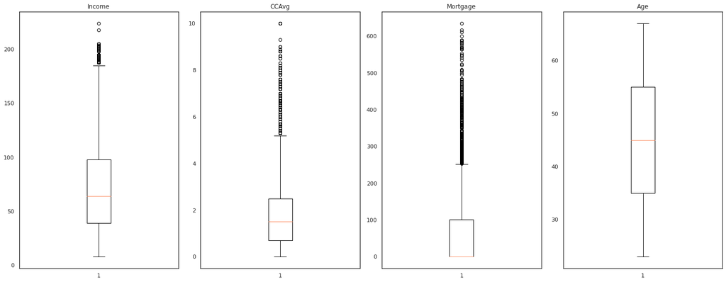

```python
numeric_columns =['Income','CCAvg','Mortgage','Age']
# outlier detection using boxplot
plt.figure(figsize=(20,30))

for i, variable in enumerate(numeric_columns):
                     plt.subplot(4,4,i+1)
                     plt.boxplot(df_loan[variable],whis=1.5)
                     plt.tight_layout()
                     plt.title(variable)

plt.show()
```

```python
# Check Income extreme values
df_loan.sort_values(by=["Income"],ascending = False).head(5)
```

|  | Age | Experience | Income | ZIPCode | Family | CCAvg | Education | Mortgage | PersonalLoan | SecuritiesAccount | CDAccount | Online | CreditCard | County | Agebin | Income_group | Spending_group | Regions |
| --- | --- | --- | --- | --- | --- | --- | --- | --- | --- | --- | --- | --- | --- | --- | --- | --- | --- | --- |
| 3896 | 48 | 24 | 224 | 93940 | 2 | 6.67000 | 1 | 0 | 0 | 0 | 1 | 1 | 1 | Monterey County | 41-50 | High | High | Bay Area |
| 4993 | 45 | 21 | 218 | 91801 | 2 | 6.67000 | 1 | 0 | 0 | 0 | 0 | 1 | 0 | Los Angeles County | 41-50 | High | High | Los Angeles Region |
| 526 | 26 | 2 | 205 | 93106 | 1 | 6.33000 | 1 | 271 | 0 | 0 | 0 | 0 | 1 | Santa Barbara County | 18-30 | High | High | Southern |
| 2988 | 46 | 21 | 205 | 95762 | 2 | 8.80000 | 1 | 181 | 0 | 1 | 0 | 1 | 0 | El Dorado County | 41-50 | High | High | Central |
| 677 | 46 | 21 | 204 | 92780 | 2 | 2.80000 | 1 | 0 | 0 | 0 | 0 | 1 | 0 | Orange County | 41-50 | High | High | Southern |

```python
df_loan.loc[(df_loan['Age']==48) & (df_loan['Experience']==24)].sort_values(by=['Income'],ascending=False).head(5)
```

|  | Age | Experience | Income | ZIPCode | Family | CCAvg | Education | Mortgage | PersonalLoan | SecuritiesAccount | CDAccount | Online | CreditCard | County | Agebin | Income_group | Spending_group | Regions |
| --- | --- | --- | --- | --- | --- | --- | --- | --- | --- | --- | --- | --- | --- | --- | --- | --- | --- | --- |
| 3896 | 48 | 24 | 224 | 93940 | 2 | 6.67000 | 1 | 0 | 0 | 0 | 1 | 1 | 1 | Monterey County | 41-50 | High | High | Bay Area |
| 196 | 48 | 24 | 165 | 93407 | 1 | 5.00000 | 1 | 0 | 0 | 0 | 0 | 0 | 1 | San Luis Obispo County | 41-50 | High | High | Southern |
| 2217 | 48 | 24 | 162 | 91355 | 4 | 3.30000 | 2 | 446 | 1 | 0 | 1 | 1 | 0 | Los Angeles County | 41-50 | High | High | Los Angeles Region |
| 4629 | 48 | 24 | 148 | 91311 | 2 | 3.30000 | 1 | 0 | 0 | 0 | 1 | 1 | 1 | Los Angeles County | 41-50 | High | High | Los Angeles Region |
| 4167 | 48 | 24 | 144 | 94025 | 4 | 3.50000 | 2 | 0 | 1 | 0 | 0 | 0 | 0 | San Mateo County | 41-50 | High | High | Bay Area |

```python
# Check Mortgage extreme values
df_loan.sort_values(by=["Mortgage"],ascending = False).head(5)
```

|  | Age | Experience | Income | ZIPCode | Family | CCAvg | Education | Mortgage | PersonalLoan | SecuritiesAccount | CDAccount | Online | CreditCard | County | Agebin | Income_group | Spending_group | Regions |
| --- | --- | --- | --- | --- | --- | --- | --- | --- | --- | --- | --- | --- | --- | --- | --- | --- | --- | --- |
| 2934 | 37 | 13 | 195 | 91763 | 2 | 6.50000 | 1 | 635 | 0 | 0 | 0 | 1 | 0 | San Bernardino County | 31-40 | High | High | Southern |
| 303 | 49 | 25 | 195 | 95605 | 4 | 3.00000 | 1 | 617 | 1 | 0 | 0 | 0 | 0 | Yolo County | 41-50 | High | High | Central |
| 4812 | 29 | 4 | 184 | 92126 | 4 | 2.20000 | 3 | 612 | 1 | 0 | 0 | 1 | 0 | San Diego County | 18-30 | High | Medium | Southern |
| 1783 | 53 | 27 | 192 | 94720 | 1 | 1.70000 | 1 | 601 | 0 | 0 | 0 | 1 | 0 | Alameda County | 51-60 | High | Medium | Bay Area |
| 4842 | 49 | 23 | 174 | 95449 | 3 | 4.60000 | 2 | 590 | 1 | 0 | 0 | 0 | 0 | Mendocino County | 41-50 | High | High | Superior |

```python
# Check CCAVg extreme values
df_loan.sort_values(by=["CCAvg"],ascending = False).head(5)
```

|  | Age | Experience | Income | ZIPCode | Family | CCAvg | Education | Mortgage | PersonalLoan | SecuritiesAccount | CDAccount | Online | CreditCard | County | Agebin | Income_group | Spending_group | Regions |
| --- | --- | --- | --- | --- | --- | --- | --- | --- | --- | --- | --- | --- | --- | --- | --- | --- | --- | --- |
| 2101 | 35 | 5 | 203 | 95032 | 1 | 10.00000 | 3 | 0 | 1 | 0 | 0 | 0 | 0 | Santa Clara County | 31-40 | High | High | Bay Area |
| 2337 | 43 | 16 | 201 | 95054 | 1 | 10.00000 | 2 | 0 | 1 | 0 | 0 | 0 | 1 | Santa Clara County | 41-50 | High | High | Bay Area |
| 787 | 45 | 15 | 202 | 91380 | 3 | 10.00000 | 3 | 0 | 1 | 0 | 0 | 0 | 0 | Los Angeles County | 41-50 | High | High | Los Angeles Region |
| 3943 | 61 | 36 | 188 | 91360 | 1 | 9.30000 | 2 | 0 | 1 | 0 | 0 | 0 | 0 | Ventura County | 60-100 | High | High | Southern |
| 1339 | 52 | 25 | 180 | 94545 | 2 | 9.00000 | 2 | 297 | 1 | 0 | 0 | 1 | 0 | Alameda County | 51-60 | High | High | Bay Area |

This is some really extreme values in income 224K USD compared to same age group and experience. Values for Credit card and Mortages looks fine.After identifying outliers, we can decide whether to remove/treat them or not. It depends,here I am not going to treat them as there will be outliers in real case scenario (in Income, Mortgage value, Average spending on the credit card, etc) and we would want our model to learn the underlying pattern for such customers.

```python
df_loan
```

|  | Age | Experience | Income | ZIPCode | Family | CCAvg | Education | Mortgage | PersonalLoan | SecuritiesAccount | CDAccount | Online | CreditCard | County | Agebin | Income_group | Spending_group | Regions |
| --- | --- | --- | --- | --- | --- | --- | --- | --- | --- | --- | --- | --- | --- | --- | --- | --- | --- | --- |
| 0 | 25 | 1 | 49 | 91107 | 4 | 1.60000 | 1 | 0 | 0 | 1 | 0 | 0 | 0 | Los Angeles County | 18-30 | Lower | Medium | Los Angeles Region |
| 1 | 45 | 19 | 34 | 90089 | 3 | 1.50000 | 1 | 0 | 0 | 1 | 0 | 0 | 0 | Los Angeles County | 41-50 | Lower | Medium | Los Angeles Region |
| 2 | 39 | 15 | 11 | 94720 | 1 | 1.00000 | 1 | 0 | 0 | 0 | 0 | 0 | 0 | Alameda County | 31-40 | Lower | Medium | Bay Area |
| 3 | 35 | 9 | 100 | 94112 | 1 | 2.70000 | 2 | 0 | 0 | 0 | 0 | 0 | 0 | San Francisco County | 31-40 | Middle | High | Bay Area |
| 4 | 35 | 8 | 45 | 91330 | 4 | 1.00000 | 2 | 0 | 0 | 0 | 0 | 0 | 1 | Los Angeles County | 31-40 | Lower | Medium | Los Angeles Region |
| ... | ... | ... | ... | ... | ... | ... | ... | ... | ... | ... | ... | ... | ... | ... | ... | ... | ... | ... |
| 4995 | 29 | 3 | 40 | 92697 | 1 | 1.90000 | 3 | 0 | 0 | 0 | 0 | 1 | 0 | Orange County | 18-30 | Lower | Medium | Southern |
| 4996 | 30 | 4 | 15 | 92037 | 4 | 0.40000 | 1 | 85 | 0 | 0 | 0 | 1 | 0 | San Diego County | 18-30 | Lower | Low | Southern |
| 4997 | 63 | 39 | 24 | 93023 | 2 | 0.30000 | 3 | 0 | 0 | 0 | 0 | 0 | 0 | Ventura County | 60-100 | Lower | Low | Southern |
| 4998 | 65 | 40 | 49 | 90034 | 3 | 0.50000 | 2 | 0 | 0 | 0 | 0 | 1 | 0 | Los Angeles County | 60-100 | Lower | Low | Los Angeles Region |
| 4999 | 28 | 4 | 83 | 92612 | 3 | 0.80000 | 1 | 0 | 0 | 0 | 0 | 1 | 1 | Orange County | 18-30 | Middle | Medium | Southern |

4999 rows × 18 columns

```python
df_loan.info()
```

```
<class 'pandas.core.frame.DataFrame'>
Int64Index: 4999 entries, 0 to 4999
Data columns (total 18 columns):
 #   Column             Non-Null Count  Dtype
---  ------             --------------  -----
 0   Age                4999 non-null   int64
 1   Experience         4999 non-null   int64
 2   Income             4999 non-null   int64
 3   ZIPCode            4999 non-null   category
 4   Family             4999 non-null   category
 5   CCAvg              4999 non-null   float64
 6   Education          4999 non-null   category
 7   Mortgage           4999 non-null   int64
 8   PersonalLoan       4999 non-null   category
 9   SecuritiesAccount  4999 non-null   category
 10  CDAccount          4999 non-null   category
 11  Online             4999 non-null   category
 12  CreditCard         4999 non-null   category
 13  County             4999 non-null   category
 14  Agebin             4999 non-null   category
 15  Income_group       4999 non-null   category
 16  Spending_group     4999 non-null   category
 17  Regions            4999 non-null   object
dtypes: category(12), float64(1), int64(4), object(1)
memory usage: 488.5+ KB
```

```python
#drop column which we don't need for modelling
df_loan.drop(columns=["Agebin", "ZIPCode","County",'Experience','Income_group','Spending_group'], inplace=True)
```

```python
df_loan.info()
```

```
<class 'pandas.core.frame.DataFrame'>
Int64Index: 4999 entries, 0 to 4999
Data columns (total 12 columns):
 #   Column             Non-Null Count  Dtype
---  ------             --------------  -----
 0   Age                4999 non-null   int64
 1   Income             4999 non-null   int64
 2   Family             4999 non-null   category
 3   CCAvg              4999 non-null   float64
 4   Education          4999 non-null   category
 5   Mortgage           4999 non-null   int64
 6   PersonalLoan       4999 non-null   category
 7   SecuritiesAccount  4999 non-null   category
 8   CDAccount          4999 non-null   category
 9   Online             4999 non-null   category
 10  CreditCard         4999 non-null   category
 11  Regions            4999 non-null   object
dtypes: category(7), float64(1), int64(3), object(1)
memory usage: 398.5+ KB
```

We have 6 categorical independent variables but 4 of them are binary, so we'll have the same results with them even after creating dummies So we will only make dummies for Regions and Education.

```python
X = df_loan.drop(['PersonalLoan'], axis=1)
Y = df_loan['PersonalLoan']

oneHotCols=['Regions','Education']
X=pd.get_dummies(X,columns=oneHotCols,drop_first=True)
```

```python
#Splitting data in train and test sets
X_train, X_test, y_train, y_test = train_test_split(X,Y, test_size=0.30, random_state = 1,stratify=Y)
```

```python
from sklearn.preprocessing import StandardScaler
# Creating StandardScaler instance
scaler = StandardScaler()

# Fitting Standard Scaller
X_scaler = scaler.fit(X_train)

# Scaling data
X_train_scaled = X_scaler.transform(X_train)
X_test_scaled = X_scaler.transform(X_test)

X_train_scaled_df = pd.DataFrame(X_train_scaled,columns=X_train.columns)
X_test_scaled_df = pd.DataFrame(X_test_scaled,columns=X_test.columns)


X_train_scaled_df.index=np.arange(len(X_train_scaled_df))
X_test_scaled_df.index=np.arange(len(X_test_scaled_df))
y_train.index=np.arange(len(y_train))
y_test.index=np.arange(len(y_test))
```

# Model building Logistic Regression

### Model evaluation criterion

### Model can make wrong predictions as:

1. Predicting a person will buy a loan but he actually doesn't.(Loss of Resource)
2. Predicting a person will not buy a loan but he actually does.(Loss of Opportunity)

### Which case is more important?

- The whole purpose of the campagin is to bring in more customers. 2nd case is more important to us .A potential customer is missed by the sales/marketing team .It's lost of opportunity.So we want to minimize this loss.

### How to reduce losses?i.e need to reduce False Negatives ?

- In this case, not being able to identify a potential customer is the biggest loss we can face. Hence, recall is the right metric to check the performance of the model.Banks wants Recall to be maximized, greater the recall lesser the chances of false negatives.
- We can use accuracy but since the data is imbalanced it would not be the right metric to check the model performance.
- Therefore, `Recall` should be maximized, the greater the Recall higher the chances of identifying both the classes correctly.

```python
def make_confusion_matrix(y_actual,y_predict,title):
    fig, ax = plt.subplots(1, 1)

    cm = confusion_matrix(y_actual, y_predict, labels=[0,1])
    disp = ConfusionMatrixDisplay(confusion_matrix=cm,
                               display_labels=["No","Yes"])
    disp.plot(cmap='Greens',colorbar=True,ax=ax)
    ax.set_title(title)
    plt.tick_params(axis=u'both', which=u'both',length=0)
    plt.grid(b=None,axis='both',which='both',visible=False)
    plt.show()
```

```python
def get_metrics_score(model,X_train_df,X_test_df,y_train_pass,y_test_pass,statsklearn,threshold=0.5,flag=True,roc=False):
    '''
    Function to calculate different metric scores of the model - Accuracy, Recall, Precision, and F1 score
    model: classifier to predict values of X
    X_train_df, X_test_df: Independent features
    y_train_pass,y_test_pass: Dependent variable
    statsklearn : 0 if calling for Sklearn model else 1
    threshold: thresold for classifiying the observation as 1
    flag: If the flag is set to True then only the print statements showing different will be displayed. The default value is set to True.
    roc: If the roc is set to True then only roc score will be displayed. The default value is set to False.
    '''
    # defining an empty list to store train and test results

    score_list=[]
    if statsklearn==0:
        pred_train = model.predict(X_train_df)
        pred_test = model.predict(X_test_df)
    else:
        pred_train = (model.predict(X_train_df)>threshold)
        pred_test = (model.predict(X_test_df)>threshold)


    pred_train = np.round(pred_train)
    pred_test = np.round(pred_test)

    train_acc = accuracy_score(y_train_pass,pred_train)
    test_acc = accuracy_score(y_test_pass,pred_test)

    train_recall = recall_score(y_train_pass,pred_train)
    test_recall = recall_score(y_test_pass,pred_test)

    train_precision = precision_score(y_train_pass,pred_train)
    test_precision = precision_score(y_test_pass,pred_test)

    train_f1 = f1_score(y_train_pass,pred_train)
    test_f1 = f1_score(y_test_pass,pred_test)


    score_list.extend((train_acc,test_acc,train_recall,test_recall,train_precision,test_precision,train_f1,test_f1))

    if flag == True:
        print("\x1b[0;30;47m \033[1mMODEL PERFORMANCE\x1b[0m")
        print("\x1b[0;30;47m \033[1mAccuracy   : Train:\x1b[0m",
              round(accuracy_score(y_train_pass,pred_train),3),
              "\x1b[0;30;47m \033[1mTest:\x1b[0m ",
              round(accuracy_score(y_test_pass,pred_test),3))
        print("\x1b[0;30;47m \033[1mRecall     : Train:\x1b[0m"
              ,round(recall_score(y_train_pass,pred_train),3),
              "\x1b[0;30;47m \033[1mTest:\x1b[0m" ,
              round(recall_score(y_test_pass,pred_test),3))

        print("\x1b[0;30;47m \033[1mPrecision  : Train:\x1b[0m",
              round(precision_score(y_train_pass,pred_train),3),
              "\x1b[0;30;47m \033[1mTest:\x1b[0m ",
              round(precision_score(y_test_pass,pred_test),3))
        print("\x1b[0;30;47m \033[1mF1         : Train:\x1b[0m",
              round(f1_score(y_train_pass,pred_train),3),
              "\x1b[0;30;47m \033[1mTest:\x1b[0m",
              round(f1_score(y_test_pass,pred_test),3))
        make_confusion_matrix(y_train_pass,pred_train,"Confusion Matrix for Train")
        make_confusion_matrix(y_test_pass,pred_test,"Confusion Matrix for Test")

    if roc == True:

        print("\x1b[0;30;47m \033[1mROC-AUC Score  :Train:\x1b[0m: ",
              round(roc_auc_score(y_train_pass,pred_train),3),
              "\x1b[0;30;47m \033[1mTest:\x1b[0m: ",
              round(roc_auc_score(y_test_pass,pred_test),3))

    return score_list # returning the list with train and test scores
```

```python
# # defining empty lists to add train and test results
acc_train = []
acc_test = []
recall_train = []
recall_test = []
precision_train = []
precision_test = []
f1_train = []
f1_test = []

def add_score_model(score):
     '''Add scores to list so that we can compare all models score together'''
     acc_train.append(score[0])
     acc_test.append(score[1])
     recall_train.append(score[2])
     recall_test.append(score[3])
     precision_train.append(score[4])
     precision_test.append(score[5])
     f1_train.append(score[6])
     f1_test.append(score[7])
```

**Logistic Regression (with Sklearn library)**

```
 MODEL PERFORMANCE
 Accuracy   : Train: 0.658  Test:  0.65
 Recall     : Train: 0.979  Test: 0.986
 Precision  : Train: 0.217  Test:  0.214
 F1         : Train: 0.355  Test: 0.351
```

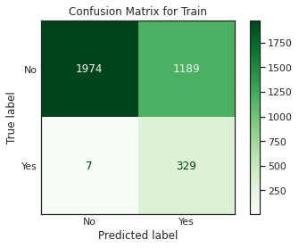

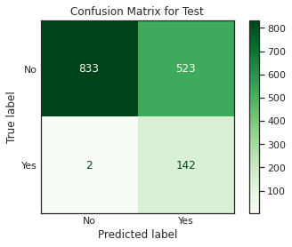

```python
lr = LogisticRegression(solver='newton-cg',random_state=1,fit_intercept=False,class_weight={0:0.15,1:0.85})
model  = lr.fit(X_train_scaled_df,y_train)

statmodel=0  #0 for sklearn and 1 for statmodel

# Let's check model performances for this model
scores_Sklearn = get_metrics_score(model,X_train_scaled_df,X_test_scaled_df,y_train,y_test,statmodel)
```

```python
add_score_model(scores_Sklearn)
```

**Logistic Regression (with Statmodel)**

```
Optimization terminated successfully.
         Current function value: 0.113898
         Iterations 9
 MODEL PERFORMANCE
 Accuracy   : Train: 0.962  Test:  0.953
 Recall     : Train: 0.688  Test: 0.653
 Precision  : Train: 0.888  Test:  0.817
 F1         : Train: 0.775  Test: 0.726
```

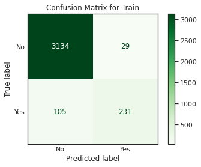

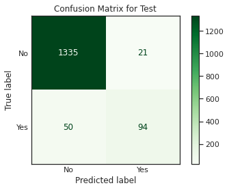

Logit Regression Results

| Dep. Variable: | PersonalLoan | No. Observations: | 3499 |
| --- | --- | --- | --- |
| Model: | Logit | Df Residuals: | 3483 |
| Method: | MLE | Df Model: | 15 |
| Date: | Fri, 11 Jun 2021 | Pseudo R-squ.: | 0.6399 |
| Time: | 05:18:29 | Log-Likelihood: | -398.53 |
| converged: | True | LL-Null: | -1106.6 |
| Covariance Type: | nonrobust | LLR p-value: | 5.492e-293 |

|  | coef | std err | z | P>\|z\| | [0.025 | 0.975] |
| --- | --- | --- | --- | --- | --- | --- |
| const | -5.2604 | 0.236 | -22.276 | 0.000 | -5.723 | -4.798 |
| Age | 0.1547 | 0.096 | 1.618 | 0.106 | -0.033 | 0.342 |
| Income | 3.0106 | 0.177 | 17.055 | 0.000 | 2.665 | 3.357 |
| Family | 0.7829 | 0.108 | 7.278 | 0.000 | 0.572 | 0.994 |
| CCAvg | 0.2176 | 0.094 | 2.310 | 0.021 | 0.033 | 0.402 |
| Mortgage | 0.0874 | 0.073 | 1.206 | 0.228 | -0.055 | 0.230 |
| SecuritiesAccount | -0.2303 | 0.112 | -2.056 | 0.040 | -0.450 | -0.011 |
| CDAccount | 0.8431 | 0.100 | 8.459 | 0.000 | 0.648 | 1.038 |
| Online | -0.3423 | 0.099 | -3.457 | 0.001 | -0.536 | -0.148 |
| CreditCard | -0.3662 | 0.116 | -3.153 | 0.002 | -0.594 | -0.139 |
| Regions_Central | -0.1968 | 0.111 | -1.781 | 0.075 | -0.413 | 0.020 |
| Regions_Los Angeles Region | -0.0451 | 0.102 | -0.444 | 0.657 | -0.244 | 0.154 |
| Regions_Southern | -0.0149 | 0.104 | -0.143 | 0.886 | -0.219 | 0.189 |
| Regions_Superior | -0.3143 | 0.216 | -1.456 | 0.145 | -0.737 | 0.109 |
| Education_2 | 1.8569 | 0.150 | 12.375 | 0.000 | 1.563 | 2.151 |
| Education_3 | 1.9912 | 0.152 | 13.101 | 0.000 | 1.693 | 2.289 |

Possibly complete quasi-separation: A fraction 0.13 of observations can be  
perfectly predicted. This might indicate that there is complete  
quasi-separation. In this case some parameters will not be identified.

```python
# adding constant to training and test set
X_train_stat = sm.add_constant(X_train_scaled_df)
X_test_stat = sm.add_constant(X_test_scaled_df)
statmodel=1  #0 for sklearn and 1 for statmodel
logit = sm.Logit( y_train, X_train_stat.astype(float) )
lg = logit.fit(warn_convergence=False)

# Let's check model performances for this model
scores_statmodel = get_metrics_score(lg,X_train_stat,X_test_stat,y_train,y_test,statmodel)
lg.summary()
```

#### MultiCollinearity

**we will have to check and remove multicollinearity from the data to get reliable coefficients and p-values.** There are different ways of detecting (or testing) multi-collinearity, one such way is the Variation Inflation Factor.* General Rule of thumb: If VIF is 1 then there is no correlation among the predictor and the remaining predictor variables. Whereas if VIF exceeds 5, we say it shows signs of high multi-collinearity. But the purpose of the analysis should dictate which threshold to use.

```python
# changing datatype of colums to numeric for checking vif
X_train_num = X_train_stat.astype(float).copy()
```

```python
vif_series1 = pd.Series([variance_inflation_factor(X_train_num.values,i) for i in range(X_train_num.shape[1])],index=X_train_num.columns, dtype = float)
print('Series before feature selection: \n\n{}\n'.format(vif_series1))
```

```
Series before feature selection:

const                        1.00000
Age                          1.01012
Income                       1.90786
Family                       1.05016
CCAvg                        1.74332
Mortgage                     1.06417
SecuritiesAccount            1.15538
CDAccount                    1.35839
Online                       1.04689
CreditCard                   1.11481
Regions_Central              1.11765
Regions_Los Angeles Region   1.22077
Regions_Southern             1.24130
Regions_Superior             1.02791
Education_2                  1.28721
Education_3                  1.25893
dtype: float64
```

```python
lg.summary()
```

Logit Regression Results

| Dep. Variable: | PersonalLoan | No. Observations: | 3499 |
| --- | --- | --- | --- |
| Model: | Logit | Df Residuals: | 3483 |
| Method: | MLE | Df Model: | 15 |
| Date: | Fri, 11 Jun 2021 | Pseudo R-squ.: | 0.6399 |
| Time: | 05:18:32 | Log-Likelihood: | -398.53 |
| converged: | True | LL-Null: | -1106.6 |
| Covariance Type: | nonrobust | LLR p-value: | 5.492e-293 |

|  | coef | std err | z | P>\|z\| | [0.025 | 0.975] |
| --- | --- | --- | --- | --- | --- | --- |
| const | -5.2604 | 0.236 | -22.276 | 0.000 | -5.723 | -4.798 |
| Age | 0.1547 | 0.096 | 1.618 | 0.106 | -0.033 | 0.342 |
| Income | 3.0106 | 0.177 | 17.055 | 0.000 | 2.665 | 3.357 |
| Family | 0.7829 | 0.108 | 7.278 | 0.000 | 0.572 | 0.994 |
| CCAvg | 0.2176 | 0.094 | 2.310 | 0.021 | 0.033 | 0.402 |
| Mortgage | 0.0874 | 0.073 | 1.206 | 0.228 | -0.055 | 0.230 |
| SecuritiesAccount | -0.2303 | 0.112 | -2.056 | 0.040 | -0.450 | -0.011 |
| CDAccount | 0.8431 | 0.100 | 8.459 | 0.000 | 0.648 | 1.038 |
| Online | -0.3423 | 0.099 | -3.457 | 0.001 | -0.536 | -0.148 |
| CreditCard | -0.3662 | 0.116 | -3.153 | 0.002 | -0.594 | -0.139 |
| Regions_Central | -0.1968 | 0.111 | -1.781 | 0.075 | -0.413 | 0.020 |
| Regions_Los Angeles Region | -0.0451 | 0.102 | -0.444 | 0.657 | -0.244 | 0.154 |
| Regions_Southern | -0.0149 | 0.104 | -0.143 | 0.886 | -0.219 | 0.189 |
| Regions_Superior | -0.3143 | 0.216 | -1.456 | 0.145 | -0.737 | 0.109 |
| Education_2 | 1.8569 | 0.150 | 12.375 | 0.000 | 1.563 | 2.151 |
| Education_3 | 1.9912 | 0.152 | 13.101 | 0.000 | 1.693 | 2.289 |

Possibly complete quasi-separation: A fraction 0.13 of observations can be  
perfectly predicted. This might indicate that there is complete  
quasi-separation. In this case some parameters will not be identified.

**In this case 'Regions' all the attributes have a high p-value which means it is not significant therefore we can drop the complete variable.**

```python
X_train1 = X_train_stat.drop(['Regions_Central', 'Regions_Los Angeles Region', 'Regions_Southern', 'Regions_Superior'], axis = 1)
X_test1= X_test_stat.drop(['Regions_Central', 'Regions_Los Angeles Region', 'Regions_Southern', 'Regions_Superior'], axis = 1)
logit1 = sm.Logit(y_train, X_train1.astype(float))
lg1 = logit1.fit(warn_convergence =False)

lg1.summary()
```

```
Optimization terminated successfully.
         Current function value: 0.114762
         Iterations 9
```

Logit Regression Results

| Dep. Variable: | PersonalLoan | No. Observations: | 3499 |
| --- | --- | --- | --- |
| Model: | Logit | Df Residuals: | 3487 |
| Method: | MLE | Df Model: | 11 |
| Date: | Fri, 11 Jun 2021 | Pseudo R-squ.: | 0.6371 |
| Time: | 05:18:33 | Log-Likelihood: | -401.55 |
| converged: | True | LL-Null: | -1106.6 |
| Covariance Type: | nonrobust | LLR p-value: | 7.885e-296 |

|  | coef | std err | z | P>\|z\| | [0.025 | 0.975] |
| --- | --- | --- | --- | --- | --- | --- |
| const | -5.1980 | 0.230 | -22.607 | 0.000 | -5.649 | -4.747 |
| Age | 0.1507 | 0.095 | 1.585 | 0.113 | -0.036 | 0.337 |
| Income | 2.9923 | 0.174 | 17.158 | 0.000 | 2.650 | 3.334 |
| Family | 0.7735 | 0.107 | 7.240 | 0.000 | 0.564 | 0.983 |
| CCAvg | 0.2112 | 0.093 | 2.266 | 0.023 | 0.028 | 0.394 |
| Mortgage | 0.0806 | 0.072 | 1.116 | 0.264 | -0.061 | 0.222 |
| SecuritiesAccount | -0.2293 | 0.113 | -2.036 | 0.042 | -0.450 | -0.009 |
| CDAccount | 0.8396 | 0.099 | 8.469 | 0.000 | 0.645 | 1.034 |
| Online | -0.3457 | 0.099 | -3.505 | 0.000 | -0.539 | -0.152 |
| CreditCard | -0.3831 | 0.116 | -3.298 | 0.001 | -0.611 | -0.155 |
| Education_2 | 1.8450 | 0.149 | 12.388 | 0.000 | 1.553 | 2.137 |
| Education_3 | 1.9776 | 0.151 | 13.123 | 0.000 | 1.682 | 2.273 |

Possibly complete quasi-separation: A fraction 0.12 of observations can be  
perfectly predicted. This might indicate that there is complete  
quasi-separation. In this case some parameters will not be identified.

**The Pvalue for Mortgage is 0.264 So droping Mortage**

```python
 X_train2 = X_train1.drop(['Mortgage'], axis = 1)
 X_test2= X_test1.drop(['Mortgage'], axis = 1)
 logit2 = sm.Logit(y_train, X_train2.astype(float))
 lg2 = logit2.fit()
 lg2.summary()
```

```
Optimization terminated successfully.
         Current function value: 0.114939
         Iterations 9
```

Logit Regression Results

| Dep. Variable: | PersonalLoan | No. Observations: | 3499 |
| --- | --- | --- | --- |
| Model: | Logit | Df Residuals: | 3488 |
| Method: | MLE | Df Model: | 10 |
| Date: | Fri, 11 Jun 2021 | Pseudo R-squ.: | 0.6366 |
| Time: | 05:18:34 | Log-Likelihood: | -402.17 |
| converged: | True | LL-Null: | -1106.6 |
| Covariance Type: | nonrobust | LLR p-value: | 1.199e-296 |

|  | coef | std err | z | P>\|z\| | [0.025 | 0.975] |
| --- | --- | --- | --- | --- | --- | --- |
| const | -5.1941 | 0.230 | -22.613 | 0.000 | -5.644 | -4.744 |
| Age | 0.1492 | 0.095 | 1.572 | 0.116 | -0.037 | 0.335 |
| Income | 3.0134 | 0.174 | 17.341 | 0.000 | 2.673 | 3.354 |
| Family | 0.7769 | 0.107 | 7.266 | 0.000 | 0.567 | 0.987 |
| CCAvg | 0.1986 | 0.092 | 2.148 | 0.032 | 0.017 | 0.380 |
| SecuritiesAccount | -0.2317 | 0.113 | -2.059 | 0.040 | -0.452 | -0.011 |
| CDAccount | 0.8427 | 0.099 | 8.495 | 0.000 | 0.648 | 1.037 |
| Online | -0.3437 | 0.098 | -3.491 | 0.000 | -0.537 | -0.151 |
| CreditCard | -0.3882 | 0.116 | -3.348 | 0.001 | -0.616 | -0.161 |
| Education_2 | 1.8369 | 0.148 | 12.371 | 0.000 | 1.546 | 2.128 |
| Education_3 | 1.9659 | 0.150 | 13.110 | 0.000 | 1.672 | 2.260 |

Possibly complete quasi-separation: A fraction 0.12 of observations can be  
perfectly predicted. This might indicate that there is complete  
quasi-separation. In this case some parameters will not be identified.

**Dropping Age as pvalue is greater than 0.05**

```python
 X_train3 = X_train2.drop(['Age'], axis = 1)
 X_test3= X_test2.drop(['Age'], axis = 1)
 logit3 = sm.Logit(y_train, X_train3.astype(float))
 lg3 = logit3.fit()
 lg3.summary()
```

```
Optimization terminated successfully.
         Current function value: 0.115294
         Iterations 9
```

Logit Regression Results

| Dep. Variable: | PersonalLoan | No. Observations: | 3499 |
| --- | --- | --- | --- |
| Model: | Logit | Df Residuals: | 3489 |
| Method: | MLE | Df Model: | 9 |
| Date: | Fri, 11 Jun 2021 | Pseudo R-squ.: | 0.6355 |
| Time: | 05:18:35 | Log-Likelihood: | -403.41 |
| converged: | True | LL-Null: | -1106.6 |
| Covariance Type: | nonrobust | LLR p-value: | 3.200e-297 |

|  | coef | std err | z | P>\|z\| | [0.025 | 0.975] |
| --- | --- | --- | --- | --- | --- | --- |
| const | -5.1735 | 0.228 | -22.704 | 0.000 | -5.620 | -4.727 |
| Income | 3.0026 | 0.173 | 17.369 | 0.000 | 2.664 | 3.341 |
| Family | 0.7691 | 0.107 | 7.196 | 0.000 | 0.560 | 0.979 |
| CCAvg | 0.1792 | 0.092 | 1.948 | 0.051 | -0.001 | 0.360 |
| SecuritiesAccount | -0.2338 | 0.112 | -2.080 | 0.037 | -0.454 | -0.014 |
| CDAccount | 0.8444 | 0.099 | 8.522 | 0.000 | 0.650 | 1.039 |
| Online | -0.3354 | 0.098 | -3.417 | 0.001 | -0.528 | -0.143 |
| CreditCard | -0.3854 | 0.116 | -3.322 | 0.001 | -0.613 | -0.158 |
| Education_2 | 1.8329 | 0.148 | 12.361 | 0.000 | 1.542 | 2.123 |
| Education_3 | 1.9513 | 0.149 | 13.106 | 0.000 | 1.659 | 2.243 |

Possibly complete quasi-separation: A fraction 0.11 of observations can be  
perfectly predicted. This might indicate that there is complete  
quasi-separation. In this case some parameters will not be identified.

CCavg is important parameter as per EDA so not dropping it

```
 MODEL PERFORMANCE
 Accuracy   : Train: 0.959  Test:  0.956
 Recall     : Train: 0.682  Test: 0.674
 Precision  : Train: 0.864  Test:  0.836
 F1         : Train: 0.762  Test: 0.746
```

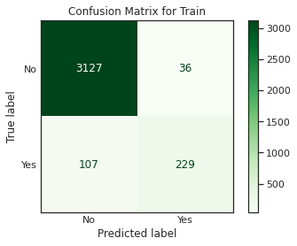

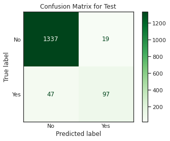

```python
# Let's check model performances for this model

scores_statmodel = get_metrics_score(lg3,X_train3,X_test3,y_train,y_test,statmodel)
add_score_model(scores_statmodel)
```

#### Roc -Auc curve on Train data

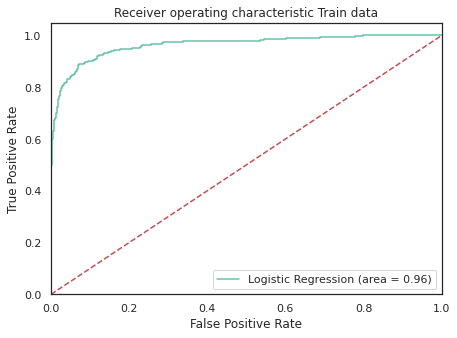

```python
logit_roc_auc_train = roc_auc_score(y_train, lg3.predict(X_train3))
fpr, tpr, thresholds = roc_curve(y_train, lg3.predict(X_train3))
plt.figure(figsize=(7,5))
plt.plot(fpr, tpr, label='Logistic Regression (area = %0.2f)' % logit_roc_auc_train)
plt.plot([0, 1], [0, 1],'r--')
plt.xlim([0.0, 1.0])
plt.ylim([0.0, 1.05])
plt.xlabel('False Positive Rate')
plt.ylabel('True Positive Rate')
plt.title('Receiver operating characteristic Train data')
plt.legend(loc="lower right")
plt.show()
```

#### Roc -Auc curve on Test data

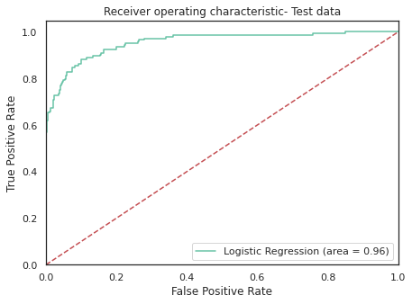

```python
logit_roc_auc_test = roc_auc_score(y_test, lg3.predict(X_test3))
fpr, tpr, thresholds = roc_curve(y_test, lg3.predict(X_test3))
plt.figure(figsize=(7,5))
plt.plot(fpr, tpr, label='Logistic Regression (area = %0.2f)' % logit_roc_auc_test)
plt.plot([0, 1], [0, 1],'r--')
plt.xlim([0.0, 1.0])
plt.ylim([0.0, 1.05])
plt.xlabel('False Positive Rate')
plt.ylabel('True Positive Rate')
plt.title('Receiver operating characteristic- Test data')
plt.legend(loc="lower right")
plt.show()
```

- Logistic Regression model is giving a generalized performance on training and test set.
- ROC-AUC score of 0.96 on training and test set is quite good.

#### Coefficient interpretations

- Coefficient of Income, Education, Family,CCavg,CD account,Age, are positive , ie a one unit increase in these will lead to increase in chances of a person borrowing loan
- Coefficient of Securities account,online ,Credit card are negative, increase in these will lead to decrease in chances of a person borrowing a loan.

#### Converting coefficients to odds

- The coefficients of the logistic regression model are in terms of log(odd), to find the odds we have to take the exponential of the coefficients.
- Therefore, **odds = exp(b)**
- Calculate the probability from the odds ratio using the formula probability = odds / (1+odds)
- The percentage change in odds is given as odds = (exp(b) - 1) * 100

```python
#Calculate Odds Ratio, probability
##create a data frame to collate Odds ratio, probability and p-value of the coef
lgcoef = pd.DataFrame(lg3.params, columns=['coef'])
lgcoef.loc[:, "Odds Ratio"] = np.exp(lgcoef.coef)
lgcoef['Probability'] = lgcoef['Odds Ratio']/(1+lgcoef['Odds Ratio'])
lgcoef['Percentage Change of Odds']=(np.exp(lg3.params)-1)*100
lgcoef['pval']=lg3.pvalues
pd.options.display.float_format = '{:.2f}'.format
lgcoef = lgcoef.sort_values(by="Odds Ratio", ascending=False)
lgcoef
```

|  | coef | Odds Ratio | Probability | Percentage Change of Odds | pval |
| --- | --- | --- | --- | --- | --- |
| Income | 3.00 | 20.14 | 0.95 | 1913.74 | 0.00 |
| Education_3 | 1.95 | 7.04 | 0.88 | 603.79 | 0.00 |
| Education_2 | 1.83 | 6.25 | 0.86 | 525.17 | 0.00 |
| CDAccount | 0.84 | 2.33 | 0.70 | 132.66 | 0.00 |
| Family | 0.77 | 2.16 | 0.68 | 115.78 | 0.00 |
| CCAvg | 0.18 | 1.20 | 0.54 | 19.63 | 0.05 |
| SecuritiesAccount | -0.23 | 0.79 | 0.44 | -20.85 | 0.04 |
| Online | -0.34 | 0.72 | 0.42 | -28.50 | 0.00 |
| CreditCard | -0.39 | 0.68 | 0.40 | -31.98 | 0.00 |
| const | -5.17 | 0.01 | 0.01 | -99.43 | 0.00 |

### Model performance evaluation and improvement

```
 MODEL PERFORMANCE
 Accuracy   : Train: 0.959  Test:  0.956
 Recall     : Train: 0.682  Test: 0.674
 Precision  : Train: 0.864  Test:  0.836
 F1         : Train: 0.762  Test: 0.746
```

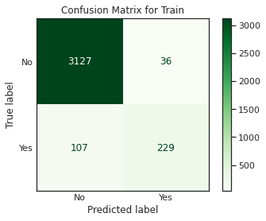

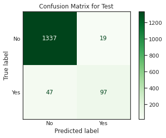

```python
# Let's check model performances for this model
scores_LR = get_metrics_score(lg3,X_train3,X_test3,y_train,y_test,statmodel)
```

**Insights:**

**True Positives:**

Reality: A customer wanted to take personal Loan. Model Prediction: The customer will take personal loan. Outcome: The model is good.

**True Negatives**:

Reality: A customer didn't wanted to take personal loan. Model Prediction: The customer will not take personal loan. Outcome: The business is unaffected .

**False Positives** :

Reality: A customer didn't want to take personal loan. Model Prediction: The customer will take personal loan. Outcome: The team which is targeting the potential customers would waste their resources on the customers who will not be buying a personal loan.

**False Negatives**:

Reality: A customer wanted to take personal Loan. Model Prediction: The customer will not take personal loan. Outcome: The potential customer is missed by the salesteam. This is loss of oppurtunity. The purpose of campaign was to target such customers. If team knew about this customers, they could have offered some good APR /interest rates.

### **Right Metric to use:**

**Here not able to identify a potential customer is the biggest loss we can face. Hence, Recall is the right metric to check the performance of the model .We have recall as `68` on train and `67` on test. False negative are `107` and `47` on train and test. We can further improve this score using Optimal threshold for ROC AUC curve and precision recall curve**

#### Optimal threshold using AUC-ROC curve

```python
# Optimal threshold as per AUC-ROC curve
# The optimal cut off would be where tpr is high and fpr is low
#fpr, tpr, thresholds = metrics.roc_curve(y_test, lg2.predict(X_test2))

optimal_idx = np.argmax(tpr - fpr)
optimal_threshold_auc_roc = thresholds[optimal_idx]
print(optimal_threshold_auc_roc)
```

```
0.09150126568446633
```

```
 MODEL PERFORMANCE
 Accuracy   : Train: 0.899  Test:  0.897
 Recall     : Train: 0.902  Test: 0.875
 Precision  : Train: 0.487  Test:  0.481
 F1         : Train: 0.633  Test: 0.621
```

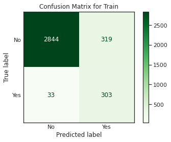

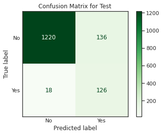

```
 ROC-AUC Score  :Train::  0.9  Test::  0.887
```

```python
scores_statmodel = get_metrics_score(lg3,X_train3,X_test3,y_train,y_test,statmodel,threshold=optimal_threshold_auc_roc,roc=True)
add_score_model(scores_statmodel)
```

##### Let's use Precision-Recall curve and see if we can find a better threshold

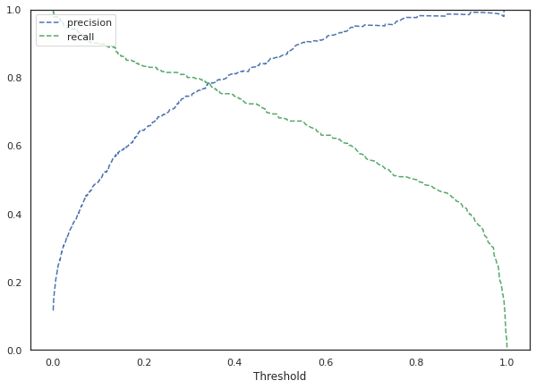

```python
y_scores=lg3.predict(X_train3)
prec, rec, tre = precision_recall_curve(y_train, y_scores,)

def plot_prec_recall_vs_tresh(precisions, recalls, thresholds):
    plt.plot(thresholds, precisions[:-1], 'b--', label='precision')
    plt.plot(thresholds, recalls[:-1], 'g--', label = 'recall')
    plt.xlabel('Threshold')
    plt.legend(loc='upper left')
    plt.ylim([0,1])
plt.figure(figsize=(10,7))
plot_prec_recall_vs_tresh(prec, rec, tre)
plt.show()
```

```
 MODEL PERFORMANCE
 Accuracy   : Train: 0.955  Test:  0.945
 Recall     : Train: 0.801  Test: 0.729
 Precision  : Train: 0.747  Test:  0.705
 F1         : Train: 0.773  Test: 0.717
```

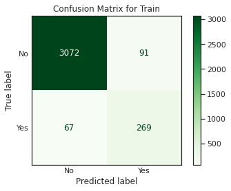

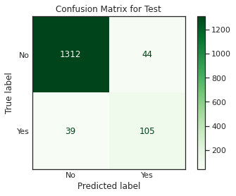

```
 ROC-AUC Score  :Train::  0.886  Test::  0.848
```

```python
optimal_threshold_curve = 0.3

scores_opt_curve = get_metrics_score(lg3,X_train3,X_test3,y_train,y_test,statmodel,threshold=optimal_threshold_curve,roc=True)
add_score_model(scores_opt_curve)
```

### Using Sequential Feature Selection

```python
X_train_seq=X_train_stat
X_test_seq=X_test_stat
```

```python
from mlxtend.feature_selection import SequentialFeatureSelector as sfs
#from sklearn.lin
X_train_seq.shape
```

```
(3499, 16)
```

```python
statmodel=0  #0 for sklearn and 1 for statmodel

clf = LogisticRegression(solver='newton-cg',random_state=1,fit_intercept=False)
# Build step forward feature selection
sfs1 = sfs(clf,k_features = 16,forward=True,
           floating=False, scoring= 'recall',
           verbose=2,
           cv=5)

 # Perform SFFS
sfs1 = sfs1.fit(X_train_seq, y_train)
```

[output not shown]

[output cut: 10 more lines]

```
[Parallel(n_jobs=1)]: Done   4 out of   4 | elapsed:    0.6s finished

[2021-06-11 05:19:07] Features: 13/16 -- score: 0.9881035996488148[Parallel(n_jobs=1)]: Using backend SequentialBackend with 1 concurrent workers.
[Parallel(n_jobs=1)]: Done   1 out of   1 | elapsed:    0.2s remaining:    0.0s
[Parallel(n_jobs=1)]: Done   3 out of   3 | elapsed:    0.5s finished

[2021-06-11 05:19:08] Features: 14/16 -- score: 0.9761633011413521[Parallel(n_jobs=1)]: Using backend SequentialBackend with 1 concurrent workers.
[Parallel(n_jobs=1)]: Done   1 out of   1 | elapsed:    0.2s remaining:    0.0s
[Parallel(n_jobs=1)]: Done   2 out of   2 | elapsed:    0.3s finished

[2021-06-11 05:19:08] Features: 15/16 -- score: 0.9791483757682178[Parallel(n_jobs=1)]: Using backend SequentialBackend with 1 concurrent workers.
[Parallel(n_jobs=1)]: Done   1 out of   1 | elapsed:    0.2s remaining:    0.0s
[Parallel(n_jobs=1)]: Done   1 out of   1 | elapsed:    0.2s finished

[2021-06-11 05:19:08] Features: 16/16 -- score: 0.672519754170325
```

```python
statmodel=0  #0 for sklearn and 1 for statmodel

clf = LogisticRegression(solver='newton-cg',random_state=1,fit_intercept=False)
# Build step forward feature selection
sfs1 = sfs(clf,k_features = 11,forward=True,
           floating=False, scoring= 'recall',
           verbose=2,
           cv=5)

 # Perform SFFS
sfs1 = sfs1.fit(X_train_seq, y_train)
```

[output not shown]

```python
# Now Which features are important?
feat_cols = list(sfs1.k_feature_idx_)
print(feat_cols)
```

```
[1, 2, 4, 5, 6, 8, 9, 10, 11, 13, 14]
```

```python
X_train_seq.columns[feat_cols]
```

```
Index(['Age', 'Income', 'CCAvg', 'Mortgage', 'SecuritiesAccount', 'Online',
       'CreditCard', 'Regions_Central', 'Regions_Los Angeles Region',
       'Regions_Superior', 'Education_2'],
      dtype='object')
```

### Now we will fit a sklearn model using these features only

```python
X_train_final = X_train_seq[X_train_seq.columns[feat_cols]]
X_test_final = X_test_seq[X_train_final.columns]
```

```
 MODEL PERFORMANCE
 Accuracy   : Train: 0.677  Test:  0.686
 Recall     : Train: 0.997  Test: 0.972
 Precision  : Train: 0.229  Test:  0.231
 F1         : Train: 0.372  Test: 0.373
```

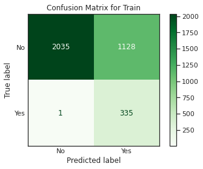

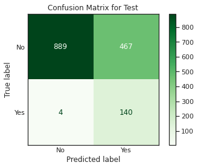

```python
lr = LogisticRegression(solver='newton-cg',random_state=1,fit_intercept=False)
model  = lr.fit(X_train_final,y_train)

statmodel=0  #0 for sklearn and 1 for statmodel

# Let's check model performances for this model
scores_sfs = get_metrics_score(model,X_train_final,X_test_final,y_train,y_test,statmodel)
add_score_model(scores_sfs)
```

```python
comparison_frame = pd.DataFrame({'Model':['Logistic Regression Model- Sklearn',
                                          'Logistic Regression Model - Statsmodels',
                                          'Logistic Regression - Optimal threshold = 0.092',
                                          'Logistic Regression - Optimal threshold = 0.3',
                                          'Logistic Regression - Sequential feature selection'
                                          ],
                                          'Train_Accuracy':acc_train,
                                          'Test_Accuracy':acc_test,
                                          'Train Recall':recall_train,
                                          'Test Recall':recall_test,
                                          'Train Precision':precision_train,
                                          'Test Precision':precision_test,
                                          'Train F1':f1_train,
                                          'Test F1':f1_test
                                })




comparison_frame
```

|  | Model | Train_Accuracy | Test_Accuracy | Train Recall | Test Recall | Train Precision | Test Precision | Train F1 | Test F1 |
| --- | --- | --- | --- | --- | --- | --- | --- | --- | --- |
| 0 | Logistic Regression Model- Sklearn | 0.66 | 0.65 | 0.98 | 0.99 | 0.22 | 0.21 | 0.35 | 0.35 |
| 1 | Logistic Regression Model - Statsmodels | 0.96 | 0.96 | 0.68 | 0.67 | 0.86 | 0.84 | 0.76 | 0.75 |
| 2 | Logistic Regression - Optimal threshold = 0.092 | 0.90 | 0.90 | 0.90 | 0.88 | 0.49 | 0.48 | 0.63 | 0.62 |
| 3 | Logistic Regression - Optimal threshold = 0.3 | 0.95 | 0.94 | 0.80 | 0.73 | 0.75 | 0.70 | 0.77 | 0.72 |
| 4 | Logistic Regression - Sequential feature selection | 0.68 | 0.69 | 1.00 | 0.97 | 0.23 | 0.23 | 0.37 | 0.37 |

Since we want higher Recall with higher accuracy Optimal Threshold 0.3 seems to be a good choice. Lets explore a model with decison tree if this score can be improved further.

# Model building Decision Tree

- Data preparation
- Partition the data into train and test set.
- Built a CART model on the train data.
- Tune the model and prune the tree, if required.
- Test the data on test set.

```python
#drop column which we don't need for modelling
df_Decision.drop(columns=["Agebin", "ZIPCode","County",'Experience','Income_group','Spending_group'], inplace=True)
```

```python
X_dt = df_Decision.drop('PersonalLoan', axis=1)
y_dt = df_Decision['PersonalLoan']
```

```python
#oneHotCols=['Regions']
oneHotCols=X_dt.select_dtypes(exclude='number').columns.to_list()
X_dt=pd.get_dummies(X_dt,columns=oneHotCols,drop_first=True)
# Spliting data set
X_train_dt, X_test_dt, y_train_dt, y_test_dt = train_test_split(X_dt, y_dt, test_size=0.3, random_state=1, stratify=y_dt)
```

#### Build Model

- We are using 'gini' criteria to split.
- If the frequency of class A is 10% and the frequency of class B is 90%, then class B will become the dominant class and the decision tree will become biased toward the dominant classes.
- To handle this imbalanced data set,we can pass a dictionary {0:0.15,1:0.85} to the model to specify the weight of each class and the decision tree will give more weightage to class 1.
- class_weight is a hyperparameter for the decision tree classifier.
- Since not being able to identify a potential customer is the biggest loss as mentioned earlier with logistic regression. Hence, recall is the right metric to check the performance of the model.

```python
##  Function to calculate recall score
def get_recall_score(model):
    '''
    model : classifier to predict values of X

    '''
    ytrain_predict = model.predict(X_train_dt)
    ytest_predict = model.predict(X_test_dt)
    # accuracy on training set
    print("\x1b[0;30;47m \033[1mAccuracy : Train :\033[0m",
          model.score(X_train_dt,y_train_dt),
          "\x1b[0;30;47m \033[1mTest:\033[0m",
          model.score(X_test_dt,y_test_dt))
# accuracy on training set
    print("\x1b[0;30;47m \033[1mRecall   : Train :\033[0m",
          metrics.recall_score(y_train_dt,ytrain_predict),
          "\x1b[0;30;47m \033[1mTest:\033[0m",
          metrics.recall_score(y_test_dt,ytest_predict))
    make_confusion_matrix(y_train_dt,ytrain_predict,"Confusion Matric on Train Data")
    make_confusion_matrix(y_test_dt,ytest_predict,"Confusion Matric on Test Data")
```

```
 Accuracy : Train : 1.0  Test: 0.984
 Recall   : Train : 1.0  Test: 0.9027777777777778
```

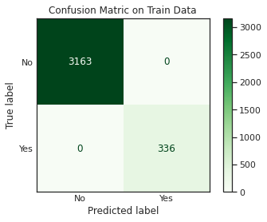

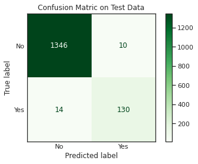

```python
#since data is imbalanced adding weights
model = DecisionTreeClassifier(criterion = 'gini',class_weight={0:0.15,1:0.85}, random_state=1)
model.fit(X_train_dt, y_train_dt)
get_recall_score(model)
```

Decision tree tends to Overfit and the disparity between the Recall on Train and Test suggest that the model is overfitted

### Visualizing the Decision Tree

```python
column_names = list(X_dt.columns)
feature_names = column_names
print(feature_names)
```

```
['Age', 'Income', 'CCAvg', 'Mortgage', 'Family_2', 'Family_3', 'Family_4', 'Education_2', 'Education_3', 'SecuritiesAccount_1', 'CDAccount_1', 'Online_1', 'CreditCard_1', 'Regions_Central', 'Regions_Los Angeles Region', 'Regions_Southern', 'Regions_Superior']
```

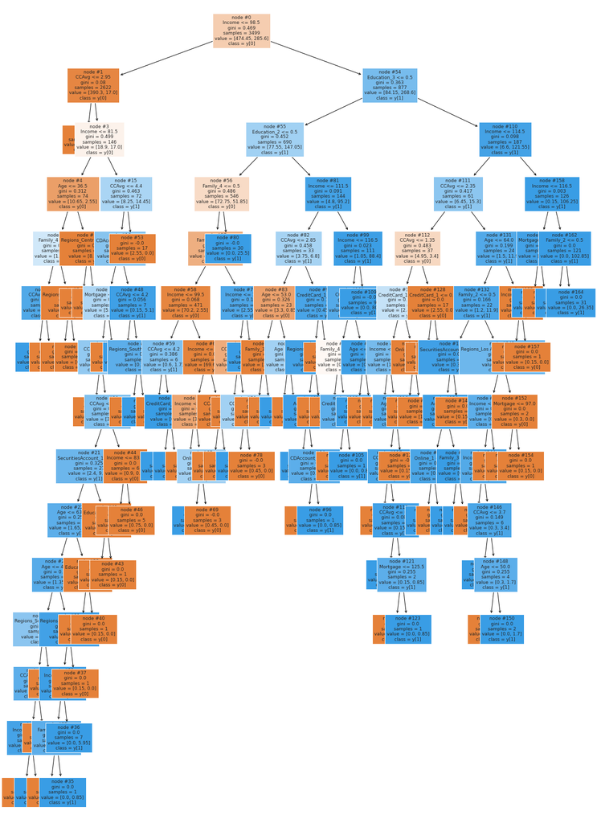

```python
plt.figure(figsize=(20,30))
from sklearn import tree
from sklearn.model_selection import GridSearchCV
out = tree.plot_tree(model,feature_names=feature_names,filled=True,fontsize=9,node_ids=True,class_names=True)
for o in out:
     arrow = o.arrow_patch
     if arrow is not None:
        arrow.set_edgecolor('black')
        arrow.set_linewidth(1)
plt.show()
```

```python
# Text report showing the rules of a decision tree -

print(tree.export_text(model,feature_names=feature_names,show_weights=True))
```

```
|--- Income <= 98.50
|   |--- CCAvg <= 2.95
|   |   |--- weights: [371.40, 0.00] class: 0
|   |--- CCAvg >  2.95
|   |   |--- Income <= 81.50
|   |   |   |--- Age <= 36.50
|   |   |   |   |--- Family_4 <= 0.50
|   |   |   |   |   |--- CCAvg <= 3.50
|   |   |   |   |   |   |--- weights: [0.00, 2.55] class: 1
|   |   |   |   |   |--- CCAvg >  3.50
|   |   |   |   |   |   |--- weights: [0.30, 0.00] class: 0
|   |   |   |   |--- Family_4 >  0.50
|   |   |   |   |   |--- Regions_Central <= 0.50
|   |   |   |   |   |   |--- weights: [1.35, 0.00] class: 0
|   |   |   |   |   |--- Regions_Central >  0.50
|   |   |   |   |   |   |--- weights: [0.30, 0.00] class: 0
|   |   |   |--- Age >  36.50
|   |   |   |   |--- Regions_Central <= 0.50
|   |   |   |   |   |--- weights: [8.25, 0.00] class: 0
|   |   |   |   |--- Regions_Central >  0.50
|   |   |   |   |   |--- weights: [0.45, 0.00] class: 0
|   |   |--- Income >  81.50
|   |   |   |--- CCAvg <= 4.40
|   |   |   |   |--- CDAccount_1 <= 0.50
|   |   |   |   |   |--- Mortgage <= 127.50
|   |   |   |   |   |   |--- CCAvg <= 3.05
|   |   |   |   |   |   |   |--- weights: [0.90, 0.00] class: 0
|   |   |   |   |   |   |--- CCAvg >  3.05
|   |   |   |   |   |   |   |--- CCAvg <= 3.95
|   |   |   |   |   |   |   |   |--- SecuritiesAccount_1 <= 0.50
|   |   |   |   |   |   |   |   |   |--- Age <= 63.50
|   |   |   |   |   |   |   |   |   |   |--- Age <= 45.50
|   |   |   |   |   |   |   |   |   |   |   |--- truncated branch of depth 4
|   |   |   |   |   |   |   |   |   |   |--- Age >  45.50
|   |   |   |   |   |   |   |   |   |   |   |--- truncated branch of depth 4
|   |   |   |   |   |   |   |   |   |--- Age >  63.50
|   |   |   |   |   |   |   |   |   |   |--- Education_2 <= 0.50
|   |   |   |   |   |   |   |   |   |   |   |--- weights: [0.15, 0.00] class: 0
|   |   |   |   |   |   |   |   |   |   |--- Education_2 >  0.50
|   |   |   |   |   |   |   |   |   |   |   |--- weights: [0.15, 0.00] class: 0
```

[output cut: 174 more lines]

```
|   |   |   |   |   |--- Income <= 113.50
|   |   |   |   |   |   |--- weights: [0.15, 0.00] class: 0
|   |   |   |   |   |--- Income >  113.50
|   |   |   |   |   |   |--- weights: [0.15, 0.00] class: 0
|   |   |--- Income >  114.50
|   |   |   |--- Income <= 116.50
|   |   |   |   |--- Mortgage <= 94.50
|   |   |   |   |   |--- weights: [0.00, 3.40] class: 1
|   |   |   |   |--- Mortgage >  94.50
|   |   |   |   |   |--- weights: [0.15, 0.00] class: 0
|   |   |   |--- Income >  116.50
|   |   |   |   |--- Family_2 <= 0.50
|   |   |   |   |   |--- weights: [0.00, 76.50] class: 1
|   |   |   |   |--- Family_2 >  0.50
|   |   |   |   |   |--- weights: [0.00, 26.35] class: 1
```

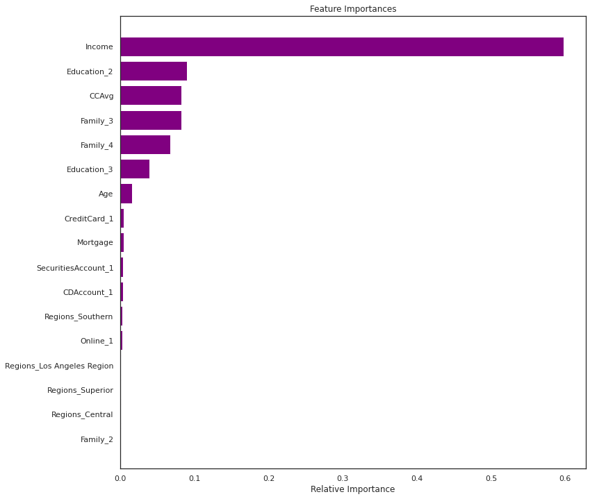

```python
importances = model.feature_importances_
indices = np.argsort(importances)

plt.figure(figsize=(12,12))
plt.title('Feature Importances')
plt.barh(range(len(indices)), importances[indices], color='purple', align='center')
plt.yticks(range(len(indices)), [feature_names[i] for i in indices])
plt.xlabel('Relative Importance')
plt.show()
```

#### Using GridSearch for Hyperparameter tuning of our tree model

- Grid search is a tuning technique that attempts to compute the optimum values of hyperparameters.
- It is an exhaustive search that is performed on a the specific parameter values of a model.
- The parameters of the estimator/model used to apply these methods are optimized by cross-validated grid-search over a parameter grid.
- Let's see if we can improve our model performance even more.

```python
# Choose the type of classifier.
estimator = DecisionTreeClassifier(random_state=1)

# Grid of parameters to choose from

parameters = {'max_depth': np.arange(1,10),
              'min_samples_leaf': [1, 2, 5, 7, 10,15,20],
              'max_leaf_nodes' : [5, 10,15,20,25,30],
              }

# Type of scoring used to compare parameter combinations
acc_scorer = metrics.make_scorer(metrics.recall_score)

# Run the grid search
grid_obj = GridSearchCV(estimator, parameters, scoring=acc_scorer,cv=5)
grid_obj = grid_obj.fit(X_train_dt, y_train_dt)

# Set the clf to the best combination of parameters
estimator = grid_obj.best_estimator_
estimator
```

```
DecisionTreeClassifier(max_depth=9, max_leaf_nodes=30, min_samples_leaf=2,
                       random_state=1)
```

```python
# Fit the best algorithm to the data.
estimator.fit(X_train_dt, y_train_dt)
ytrain_predict=estimator.predict(X_train_dt)
ytest_predict=estimator.predict(X_test_dt)
```

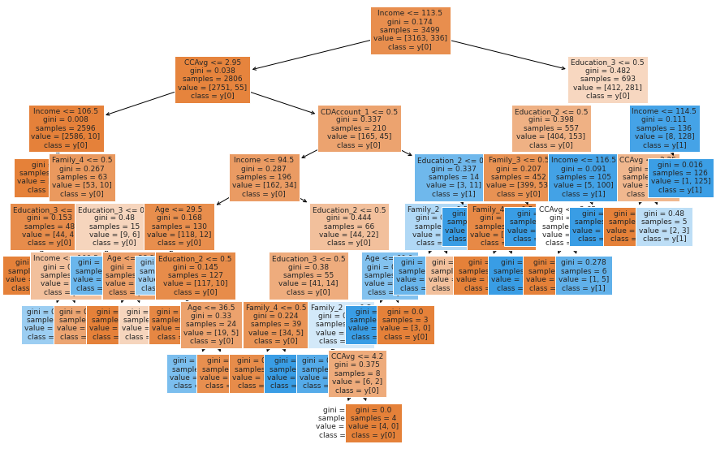

```python
plt.figure(figsize=(15,10))

out = tree.plot_tree(estimator,feature_names=feature_names,filled=True,fontsize=9,node_ids=False,class_names=True)
for o in out:
    arrow = o.arrow_patch
    if arrow is not None:
        arrow.set_edgecolor('black')
        arrow.set_linewidth(1)
plt.show()
```

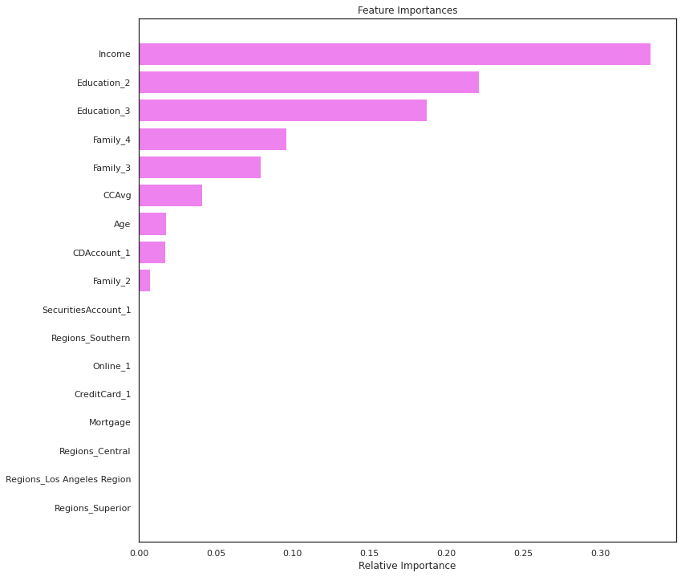

```python
importances = estimator.feature_importances_
indices = np.argsort(importances)

plt.figure(figsize=(12,12))
plt.title('Feature Importances')
plt.barh(range(len(indices)), importances[indices], color='violet', align='center')
plt.yticks(range(len(indices)), [feature_names[i] for i in indices])
plt.xlabel('Relative Importance')
plt.show()
```

```
 Accuracy : Train : 0.992283509574164  Test: 0.984
 Recall   : Train : 0.9494047619047619  Test: 0.9166666666666666
```

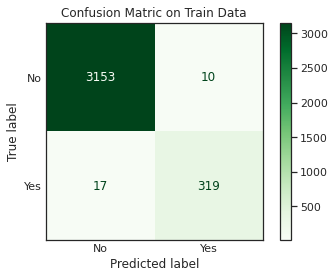

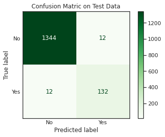

```python
get_recall_score(estimator)
```

#### Cost Complexity Pruning

```python
clf = DecisionTreeClassifier(random_state=1)
path = clf.cost_complexity_pruning_path(X_train_dt, y_train_dt)
ccp_alphas, impurities = path.ccp_alphas, path.impurities
```

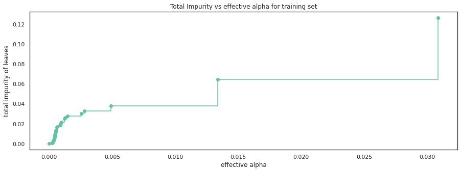

```python
fig, ax = plt.subplots(figsize=(15,5))
ax.plot(ccp_alphas[:-1], impurities[:-1], marker='o', drawstyle="steps-post")
ax.set_xlabel("effective alpha")
ax.set_ylabel("total impurity of leaves")
ax.set_title("Total Impurity vs effective alpha for training set")
plt.show()
```

Next, we train a decision tree using the effective alphas. We will set these values of alpha and pass it to the ccp_alpha parameter of our DecisionTreeClassifier. By looping over the alphas array, we will find the accuracy on both Train and Test parts of our dataset.

```python
clfs = []
accuracy_train=[]
accuracy_test=[]
recall_train=[]
recall_test=[]
for ccp_alpha in ccp_alphas:
    clf = DecisionTreeClassifier(random_state=1, ccp_alpha=ccp_alpha,class_weight = {0:0.15,1:0.85})
    clf.fit(X_train_dt, y_train_dt)
    y_train_pred=clf.predict(X_train_dt)
    y_test_pred=clf.predict(X_test_dt)
    accuracy_train.append(clf.score(X_train_dt,y_train_dt))
    accuracy_test.append(clf.score(X_test_dt,y_test_dt))
    recall_train.append(metrics.recall_score(y_train_dt,y_train_pred))
    recall_test.append(metrics.recall_score(y_test_dt,y_test_pred))
    clfs.append(clf)
```

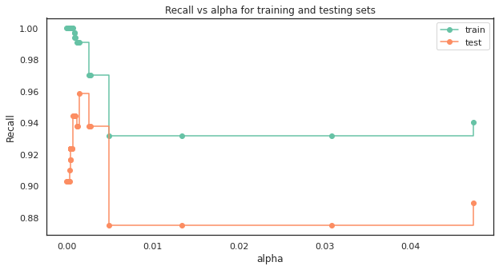

```python
fig, ax = plt.subplots(figsize=(10,5))
ax.set_xlabel("alpha")
ax.set_ylabel("Recall")
ax.set_title("Recall vs alpha for training and testing sets")
ax.plot(ccp_alphas, recall_train, marker='o', label="train",
        drawstyle="steps-post")
ax.plot(ccp_alphas, recall_test, marker='o', label="test",
        drawstyle="steps-post")
ax.legend()
plt.show()
```

We are gettingt a higher recall on test data between 0.002 to 0.005. Will choose alpha as **0.002.**

#### Creating model with 0.002 ccp_alpha

```python
best_model = DecisionTreeClassifier(ccp_alpha=0.002,
                       class_weight={0: 0.15, 1: 0.85}, random_state=1)
best_model.fit(X_train_dt, y_train_dt)
```

```
DecisionTreeClassifier(ccp_alpha=0.002, class_weight={0: 0.15, 1: 0.85},
                       random_state=1)
```

```
 Accuracy : Train : 0.9794226921977708  Test: 0.9753333333333334
 Recall   : Train : 0.9791666666666666  Test: 0.9583333333333334
```

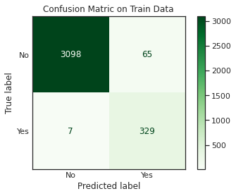

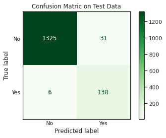

```python
get_recall_score(best_model)
```

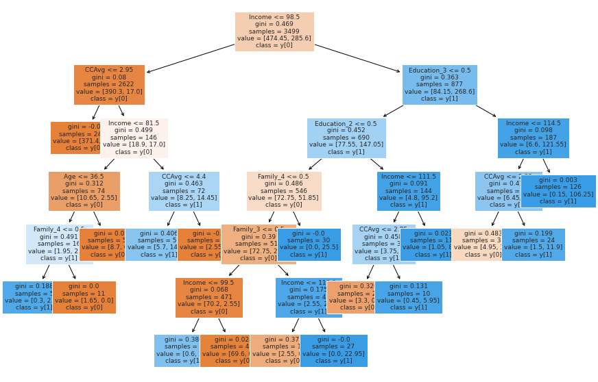

```python
plt.figure(figsize=(15,10))

out = tree.plot_tree(best_model,feature_names=feature_names,filled=True,fontsize=9,node_ids=False,class_names=True)
for o in out:
    arrow = o.arrow_patch
    if arrow is not None:
        arrow.set_edgecolor('black')
        arrow.set_linewidth(1)
plt.show()
```

```python
# Text report showing the rules of a decision tree -

print(tree.export_text(best_model,feature_names=feature_names,show_weights=True))
```

```
|--- Income <= 98.50
|   |--- CCAvg <= 2.95
|   |   |--- weights: [371.40, 0.00] class: 0
|   |--- CCAvg >  2.95
|   |   |--- Income <= 81.50
|   |   |   |--- Age <= 36.50
|   |   |   |   |--- Family_4 <= 0.50
|   |   |   |   |   |--- weights: [0.30, 2.55] class: 1
|   |   |   |   |--- Family_4 >  0.50
|   |   |   |   |   |--- weights: [1.65, 0.00] class: 0
|   |   |   |--- Age >  36.50
|   |   |   |   |--- weights: [8.70, 0.00] class: 0
|   |   |--- Income >  81.50
|   |   |   |--- CCAvg <= 4.40
|   |   |   |   |--- weights: [5.70, 14.45] class: 1
|   |   |   |--- CCAvg >  4.40
|   |   |   |   |--- weights: [2.55, 0.00] class: 0
|--- Income >  98.50
|   |--- Education_3 <= 0.50
|   |   |--- Education_2 <= 0.50
|   |   |   |--- Family_4 <= 0.50
|   |   |   |   |--- Family_3 <= 0.50
|   |   |   |   |   |--- Income <= 99.50
|   |   |   |   |   |   |--- weights: [0.60, 1.70] class: 1
|   |   |   |   |   |--- Income >  99.50
|   |   |   |   |   |   |--- weights: [69.60, 0.85] class: 0
|   |   |   |   |--- Family_3 >  0.50
|   |   |   |   |   |--- Income <= 118.00
|   |   |   |   |   |   |--- weights: [2.55, 0.85] class: 0
|   |   |   |   |   |--- Income >  118.00
|   |   |   |   |   |   |--- weights: [0.00, 22.95] class: 1
|   |   |   |--- Family_4 >  0.50
|   |   |   |   |--- weights: [0.00, 25.50] class: 1
|   |   |--- Education_2 >  0.50
|   |   |   |--- Income <= 111.50
|   |   |   |   |--- CCAvg <= 2.85
|   |   |   |   |   |--- weights: [3.30, 0.85] class: 0
|   |   |   |   |--- CCAvg >  2.85
|   |   |   |   |   |--- weights: [0.45, 5.95] class: 1
|   |   |   |--- Income >  111.50
|   |   |   |   |--- weights: [1.05, 88.40] class: 1
|   |--- Education_3 >  0.50
|   |   |--- Income <= 114.50
|   |   |   |--- CCAvg <= 2.35
|   |   |   |   |--- weights: [4.95, 3.40] class: 0
|   |   |   |--- CCAvg >  2.35
|   |   |   |   |--- weights: [1.50, 11.90] class: 1
|   |   |--- Income >  114.50
|   |   |   |--- weights: [0.15, 106.25] class: 1
```

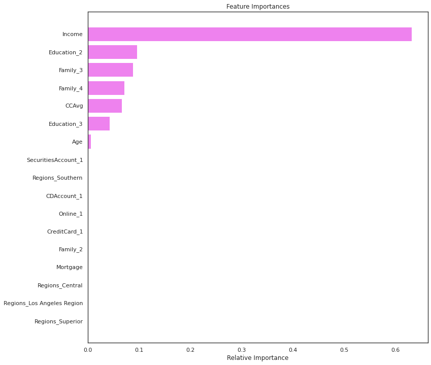

```python
importances = best_model.feature_importances_
indices = np.argsort(importances)

plt.figure(figsize=(12,12))
plt.title('Feature Importances')
plt.barh(range(len(indices)), importances[indices], color='violet', align='center')
plt.yticks(range(len(indices)), [feature_names[i] for i in indices])
plt.xlabel('Relative Importance')
plt.show()
```